# Lecture_02_perceptron slides

## 10-315 Introduction to Machine Learning (SCS Majors) Lecture 2: The Perceptron

### Leila Wehbe Carnegie Mellon University Machine Learning Department

Lecture based on [chapter 4](http://ciml.info/dl/v0_99/ciml-v0_99-ch04.pdf) from Hal Daumé III, on Kilian Weinberger's [lecture 3](https://www.cs.cornell.edu/courses/cs4780/2018fa/lectures/lecturenote03.html), on Tom Mitchell's [lecture 1](http://www.cs.cmu.edu/~tom/10701-S20/Intro-DTreesAndOverfitting-1-13-2020.pdf) and Matt Gormley's [lecture 1](https://www.cs.cmu.edu/~mgormley/courses/10601-f23//slides/lecture1-overview-ink.pdf).

#### Lecture outcomes

- Definition of linear separator
- Perceptron algorithm
- Perceptron algorithm guarantees
- Definition of margin

### Links (use the version you need)

- [Notebook](https://github.com/lwehbe/10315/blob/F24/Lecture_02_perceptron.ipynb)
- [PDF slides](https://github.com/lwehbe/10315/raw/F24/Lecture_02_perceptron.slides.pdf)

### Supervised Learning Problem Statement

The goal is to learn a function $c^*$ that maps input variables $X$ to output variables $y$, based on a set of labeled training examples.

- classification: $y$ is binary or multiclass
- regression: $y$ is continuous

**Training Data:** Given a training set of $n$ labeled examples:$\{(X_1, y_1), (X_2, y_2), \dots, (X_n, y_n)\},$ where $X_i \in \mathcal{X} $ represents the input features and $y_i \in \mathcal{Y} $ represents the corresponding labels, the goal is to estimate the optimal function $c^*$ that best predicts the labels for new, unseen data.

**Hypothesis Space:** The function $c^*$ is chosen from a family of hypotheses $ \mathcal{H} $. That is, $ c^* \in \mathcal{H} $, where $ \mathcal{H}$ represents the set of all possible functions that could map inputs to outputs.

**Learning Rule:** A learning rule is applied to select the optimal function $c^* $ from the hypothesis space $\mathcal{H}$. The learning rule is typically defined based on an optimization algorithm that seeks to minimize a cost function over the training data.

### Supervised Learning Problem Statement (continued)

**Loss Function:** A loss function $L(y, \hat{y})$ quantifies the error between the predicted value $\hat{y} = c(X)$ and the actual value $y$ for a single data point.

- Examples of Loss Functions
  - **0-1 Loss (for Classification)**: The 0-1 loss function is used in classification tasks and is defined for. single point as: $$ L(y, \hat{y}) = \begin{cases} 0, & \text{if } y = \hat{y} \\ 1, & \text{if } y \neq \hat{y} \end{cases} $$ This loss function counts the number of incorrect predictions, and the goal is to minimize the number of errors.
  - The loss over a dataset (also refered to as the error rate): $\frac{1}{n} \sum_{i=1}^n L(y_i, \hat{y}_i)$

**Test Data:** A set of $m$ labeled examples:$\{(X_j, y_j), j\in 1 \dots m\},$ which is sampled from the same distribution as the training set.

### Class outline:

- Supervised learning:
  - Perceptron

## The Perceptron

- Introduced by Rosenblatt in 1958
- Inspired by real neurons

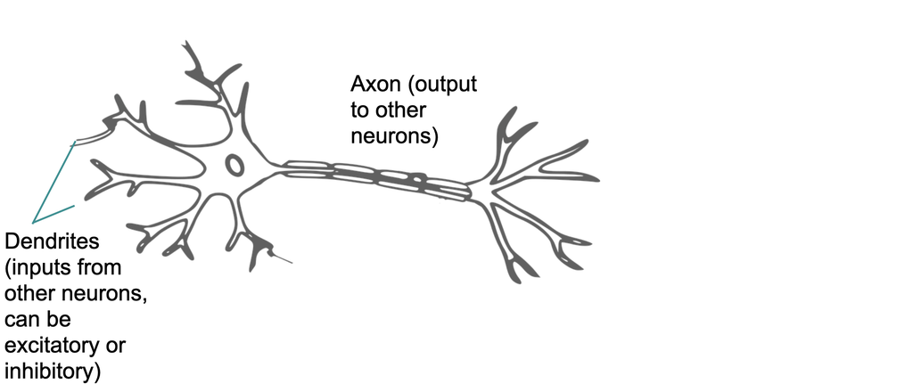

## The Perceptron

- Introduced by Rosenblatt in 1958
- Inspired by real neurons

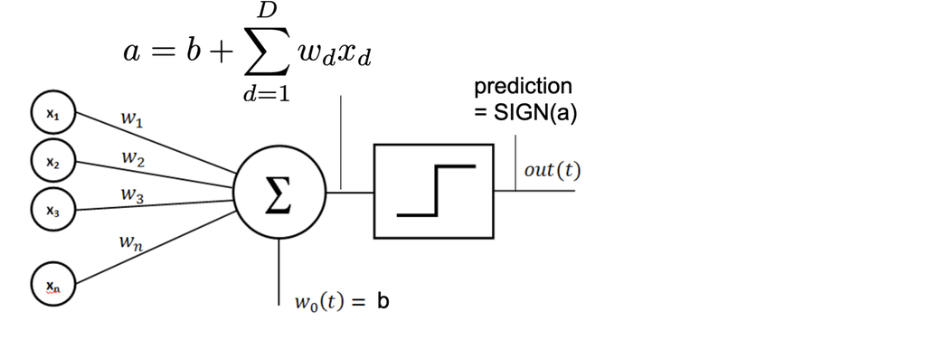

## The Perceptron

- Assume data is binary
- Assume data is linearly separable:
  - there exist a hyperplane that perfectly divides the two classes

#### Refresher:

- Recall how to define a hyperplane:
  - a subspace whose dimension is one less than that of its ambient space
  - if x is d-dimensional:
    - $\langle {\bf x},w \rangle + b = 0$
    - ($w$ also d-dimensional)

```python
import matplotlib.pyplot as plt
%matplotlib inline
import numpy as np
plt.rcParams['text.usetex'] = True
import warnings
warnings.filterwarnings('ignore')
```

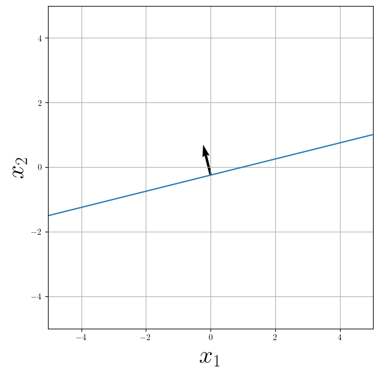

```python
def plot_line(ax,xlims, w, do_norm=True):
    x1 = np.linspace(xlims[0],xlims[1],1000)
    x2_plot = (- w[2] - w[0]*x1)/w[1]  #  w[0]*x1 + w[1]*x2 + w[2] = 0
    ax.plot(x1,x2_plot)
    origin = x1[np.array(x1.shape[0]/2).astype(int)], x2_plot[int(x1.shape[0]/2)]
    nn = np.linalg.norm(w) if do_norm else 1
    ax.quiver(*origin, w[0]/nn,w[1]/nn, color='k',angles='xy', scale_units='xy', scale=1)
    ax.axis('equal')
    ax.axis([xlims[0],xlims[1],xlims[0],xlims[1]])
    ax.set_xlabel(r'$x_1$',fontsize=30); ax.set_ylabel(r'$x_2$',fontsize=30)
    ax.grid()

w = [-5,20]
b = 5
f, ax = plt.subplots(figsize=(7,7))
plot_line(ax, [-5,5], [w[0],w[1],b])
```

## The Perceptron

- Assume data is binary
- Assume data is linearly separable:
  - i.e, there exist a hyperplane that perfectly divides the two classes \begin{align}\exists {\bf w},b ~ ~ \text{ s.t. } ~ ~ \forall({\bf x}_i,y_i) \in D,\\ y_i({\bf w}^\top {\bf x}_i +b)>0 \end{align}

\begin{align}\exists {\bf w},b ~ ~ \text{ s.t. } ~ ~ \forall({\bf x}_i,y_i) \in D,\\ y_i({\bf w}^\top {\bf x}_i +b)>0 \end{align}

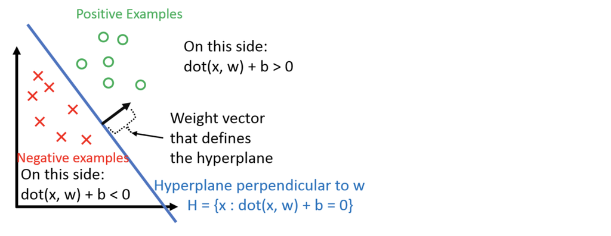

[source](https://www.cs.cornell.edu/courses/cs4780/2018fa/lectures/lecturenote03.html)

### What is a separable dataset?

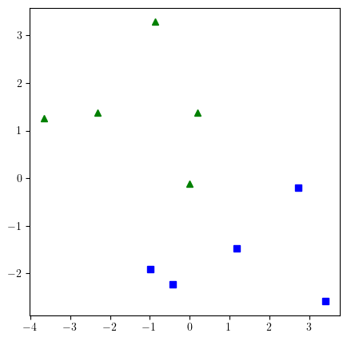

```python
from sklearn import datasets

X, y = datasets.make_blobs(n_samples=10, centers=np.array([[-1,1],[1,-1]]),
                           n_features=2, center_box=(0, 10))
y[y==0] = -1

def plot_dataset(ax,X,y):
    ax.plot(X[:, 0][y == -1], X[:, 1][y == -1], 'g^')
    ax.plot(X[:, 0][y == 1], X[:, 1][y == 1], 'bs');

f, ax = plt.subplots(figsize=(5,5))
plot_dataset(ax,X,y)
```

### Simplifying $w$ and $b$

- We can write ${\bf x}_i$ as:

  \begin{align} {\bf x_i}' &= \begin{bmatrix} {\bf x_i} \\ 1 \end{bmatrix} \end{align}
- and incorporate $b$ into ${\bf w}$:

\begin{align} {\bf w}' &= \begin{bmatrix} {\bf w} \\ b \end{bmatrix} \end{align}

- The same hyperplane is now defined by $ {\bf w'}^\top{\bf x'} = 0$
- Why does this work?
- We will use ${\bf w}$ and ${\bf x}$ to refer to these vectors in the rest of the lecture.

### The perceptron training algorithm

- Initialize ${\bf w} = {\bf 0}$
- while TRUE do
  - $m$ = 0
  - for $({\bf x}_i, y_i) \in D$ do
    - if $y_i({\bf w}^\top{\bf x}_i)\le 0$ then % if the tuple $({\bf x}_i, y_i)$ is misclassified
      - ${\bf w}\leftarrow {\bf w}+y_i{\bf x}_i$ %update the weight vector ${\bf w}$
      - $m$ = $m$+1 %count number of misclassified examples in this round
  - end for
  - if m=0 %if no examples were misclassified in this round
    - break %break out of the loop
  - end if
- end while

#### Questions:

- how does convergence happen?
- what happens if the data is not separable?

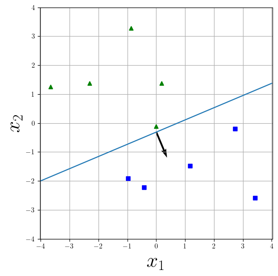

```python
def perceptron_train(X,y,MaxIter=20):
    w = np.zeros((X.shape[1]))
    for i in range(MaxIter):
        m = 0
        for (xi,yi) in zip(X,y):
            if yi*w.T.dot(xi)<=0:
                w = w + yi*xi
                m = m + 1
        if m==0:
            break
    return w

f,ax = plt.subplots(figsize=(6,6))
plot_dataset(ax,X,y)
Xprime = np.hstack([X,np.ones((X.shape[0],1))])
w = perceptron_train(Xprime,y)
plot_line(ax,[-4,4], w)
```

```python
def perceptron_train_and_plot(axs,X,y,MaxIter=20):
    w = np.zeros((X.shape[1]))
    plot_dataset(axs[0],X,y)
    plot_line(axs[0],[-4,4], w)
    plt_cnt = 0
    for i in range(MaxIter):
        m = 0
        for (xi,yi) in zip(X,y):
            if yi*w.T.dot(xi)<=0:
                w = w + yi*xi
                m = m + 1
                plt_cnt = plt_cnt + 1
                try:
                    if yi == -1:
                        axs[plt_cnt-1].plot([xi[0]],[xi[1]],'g^',markersize=10)
                    else:
                        axs[plt_cnt-1].plot([xi[0]],[xi[1]],'bs',markersize=10)
                    plot_dataset(axs[plt_cnt],X,y)
                    plot_line(axs[plt_cnt],[-4,4], w, do_norm=False)
                except:
                    print('not enough subplots')
        if m==0:
            break
    return w
```

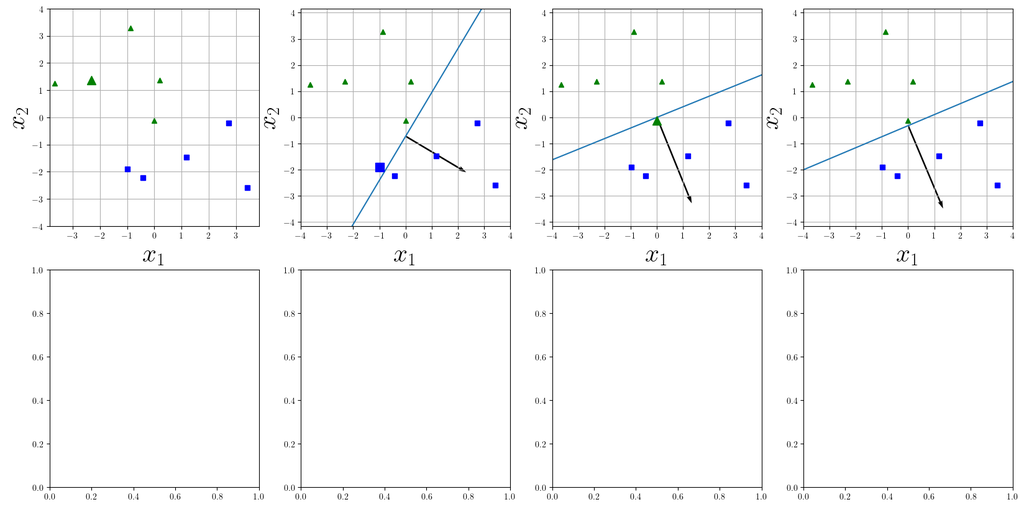

```python
f,axs = plt.subplots(nrows=2,ncols=4,figsize=(20,10))
w = perceptron_train_and_plot(axs.reshape(-1),Xprime,y)
```

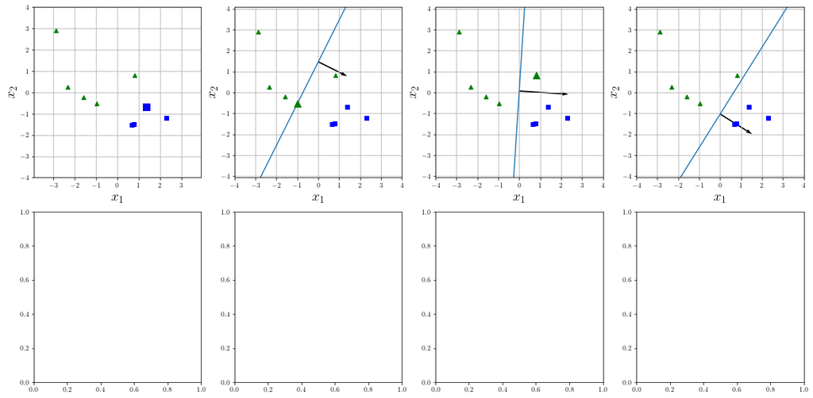

```python
X, y = datasets.make_blobs(n_samples=10, centers=np.array([[-1,1],[1,-1]]),
                           n_features=2, center_box=(0, 10))
y[y==0] = -1
Xprime = np.hstack([X,np.ones((X.shape[0],1))])
f,axs = plt.subplots(nrows=2,ncols=4,figsize=(20,10))
w = perceptron_train_and_plot(axs.reshape(-1),Xprime,y)
```

## Why does this training algorithm work?

- what happens if you missclassify a positive example?
  - this means $y_i({\bf w^k}^\top{\bf x_i})\le 0$, and in other words $ {\bf w^k}^\top{\bf x_i} < 0$)
  - the weights get updated: $${\bf w^{k+1}} = {\bf w^k} + {\bf x_i}$$
  - what happens to the dot product $({\bf w}^\top{\bf x_i})$?

\begin{align} {\bf w^{k+1}}^\top{\bf x_i} &= ({\bf w^k} + {\bf x_i})^\top{\bf x_i}\\ &= {\bf w^k}^\top{\bf x_i} + {\bf x_i}^\top{\bf x_i}\\ &> {\bf w^k}^\top{\bf x_i} \end{align}

- The prediction becomes more positive (vice versa for a negative example).
- Thus the boundary is getting closer to correctly classiying ${\bf x_i}$.

## How many iterations are needed with a dataset with one example?

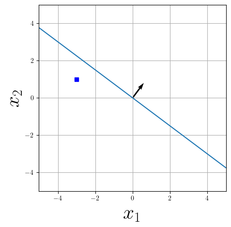

```python
f, ax = plt.subplots(figsize=(5,5))
plot_line(ax, [-5,5], [3,4,0])
ax.plot([-3],[1],'bs')
```

## Convergence of the perceptron algorithm

- The perceptron algorithm converges in $\frac{1}{\gamma^2}$ updates if the data is linearly separable.
- $\gamma$ is the margin of the problem instance (defined on next slide).

#### Notion of Margin

- Assume there exists ${\bf w}^*$ such that $ ~ ~ \forall({\bf x_i},y_i) \in D$, $ ~ ~ ~ y_i({\bf x_i}^\top {\bf w}^*)>0$
- Also assume we rescale ${\bf w}^*$ and the ${\bf x_i}$s such that:
  - $||{\bf w}^*||=1 ~ ~ ~ $ and $~ ~ ~ ||{\bf x_i}||\le1 ~ ~ \forall {\bf x_i} $ $~~~~~$(how?)
- The margin $\gamma$ of the hyperplane ${\bf w}^*$ is the minimum distance between one of the points and the hyperplane:
  - $\gamma = \min_{({\bf x_i},y_i)\in \mathcal{D}} |{\bf x_i}^\top {\bf w}^*|$ $~~~~~$(since ${\bf w}^*$ is unit norm)

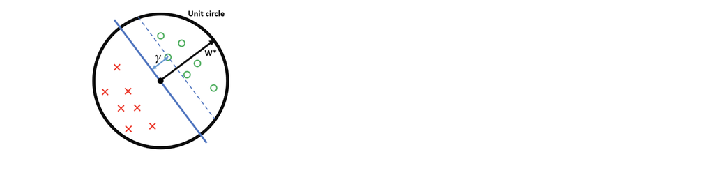

    [source](https://www.cs.cornell.edu/courses/cs4780/2018fa/lectures/lecturenote03.html)

### Theorem

- Given:
  - All ${\bf x}_i$s are within the unit sphere
  - There exists a separating hyperplane ${\bf w}^*$, with $||{\bf w}^*||=1$
  - $\gamma$ is the margin of hyperplane ${\bf w}^*$
- If all of the above holds, then the Perceptron algorithm makes at most $\frac{1}{\gamma^2}$ mistakes.

##### Questions:

- Is it easier to train when the margin is small or large?
- What types of datasets will converge quickly?

## Proof

[source](https://www.cs.cornell.edu/courses/cs4780/2018fa/lectures/lecturenote03.html)

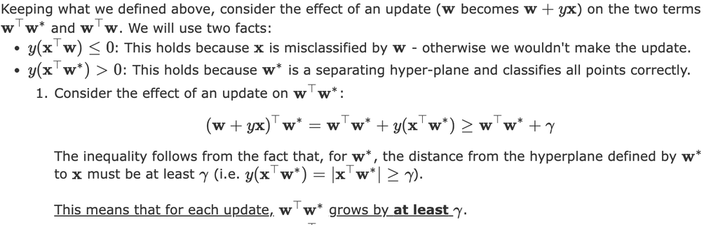

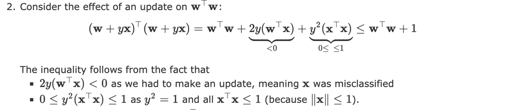

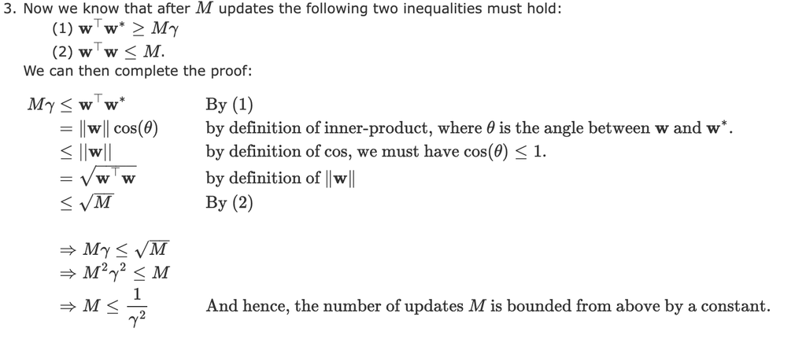

### Questions

- What happens if the data is not separable?
- Does the order matter?
- Is the perceptron guaranteed to find an optimal solution?

### Answers:

- the algorithm doens't converge
- different orders of points might lead to faster or slower convergence, and to a different ${\bf w}$ and different hyperplane
- no, it is only guaranteed to find a solution if one exists. It does not look for the maximum margin separator.